# The Art of Comparison

Matching, Weighting, and the Quest for Valid Counterfactuals

Jonathan Seward

Spring 2026

# The Comparison Problem

Why Naive Comparisons Fail

## The Fundamental Challenge

**The Core Question**

How do we know what *would have happened* if someone hadn’t received treatment?

We never observe the same person both treated and untreated at the same time.

**Our solution:** Find someone *similar enough* who wasn’t treated and use their outcome as the counterfactual.

But “similar enough” is doing a lot of heavy lifting here…

## When Comparisons Go Wrong

Consider a study of hospital quality:

**Show R Code**

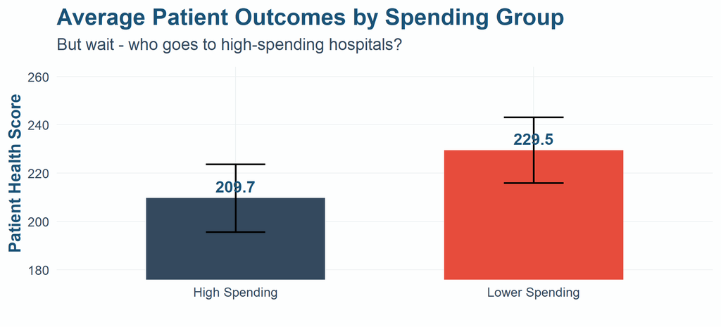

Figure 1: Naive comparison suggests high-spending hospitals are worse!

```r
hospital_summary <- hospital_data %>%
  group_by(high_spending) %>%
  summarize(
    mean_outcome = mean(outcome_score),
    se = sd(outcome_score) / sqrt(n()),
    mean_severity = mean(severity),
    .groups = "drop"
  ) %>%
  mutate(hospital_type = ifelse(high_spending == 1, "High Spending", "Lower Spending"))

ggplot(hospital_summary, aes(x = hospital_type, y = mean_outcome, fill = hospital_type)) +
  geom_col(width = 0.6) +
  geom_errorbar(aes(ymin = mean_outcome - 1.96*se, ymax = mean_outcome + 1.96*se),
                width = 0.2, linewidth = 1) +
  geom_text(aes(label = round(mean_outcome, 1)), vjust = -0.5, size = 6,
            fontface = "bold", color = primary_blue) +
  scale_fill_manual(values = c(slate_gray, accent_coral), guide = "none") +
  labs(
    title = "Average Patient Outcomes by Spending Group",
    subtitle = "But wait - who goes to high-spending hospitals?",
    x = "", y = "Patient Health Score"
  ) +
  theme_health_econ(base_size = 18) +
  coord_cartesian(ylim = c(180, 260))
```

## The Hidden Story: Selection

**Show R Code**

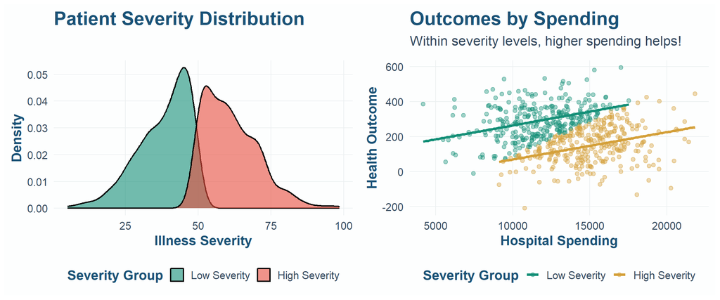

Figure 2: High-spending hospitals treat sicker patients

```r
p1 <- ggplot(hospital_data, aes(x = severity, fill = severity_group)) +
  geom_density(alpha = 0.6) +
  scale_fill_manual(values = c(secondary_teal, accent_coral),
                    name = "Severity Group") +
  labs(title = "Patient Severity Distribution",
       x = "Illness Severity", y = "Density") +
  theme_health_econ(base_size = 16) +
  theme(legend.position = "bottom")

p2 <- ggplot(hospital_data, aes(x = spending, y = outcome_score, color = severity_group)) +
  geom_point(alpha = 0.4, size = 2) +
  geom_smooth(method = "lm", se = FALSE, linewidth = 1.5) +
  scale_color_manual(values = c(secondary_teal, warm_gold, accent_coral),
                     name = "Severity Group") +
  labs(title = "Outcomes by Spending",
       subtitle = "Within severity levels, higher spending helps!",
       x = "Hospital Spending", y = "Health Outcome") +
  theme_health_econ(base_size = 16) +
  theme(legend.position = "bottom")

p1 + p2
```

## The Selection Bias Formula

The naive difference in outcomes can be decomposed:

$$\underbrace{E[Y|D=1] - E[Y|D=0]}_{\text{What we observe}} = \underbrace{E[Y^1 - Y^0|D=1]}_{\text{ATT (what we want)}} + \underbrace{E[Y^0|D=1] - E[Y^0|D=0]}_{\text{Selection Bias}}$$

**Selection bias** arises when treated and untreated groups differ in their *baseline* potential outcomes.

In our hospital example: sicker patients end up in higher-spending hospitals, so $E[Y^0|D=1] < E[Y^0|D=0]$.

**Graduate Students: Full Decomposition**

The SDO can also be written as: $SDO = ATT + [E[Y^0|D=1] - E[Y^0|D=0]]$ or equivalently $SDO = ATU + [E[Y^1|D=1] - E[Y^1|D=0]]$. The second term captures selection on levels (baseline differences) while treatment effect heterogeneity appears in the difference between ATT and ATE.

## From Comparison to Unconfoundedness

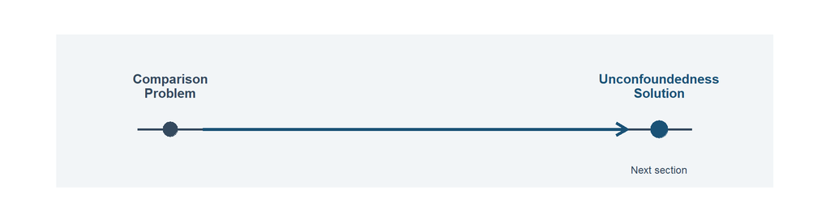

Figure 3

# The Unconfoundedness Solution

Designing Valid Counterfactuals

## Design Trumps Analysis

**The Golden Rule**

The quality of your causal estimate depends more on your *design* than your statistical sophistication.

### Good Design

- Thoughtful selection of comparison group
- Identifying relevant confounders *before* analysis
- Understanding the assignment mechanism

### Risky Practice

- Running many models until one “works”
- Adding controls post-hoc
- Ignoring institutional details

## The Unconfoundedness Assumption

**Core Idea**

If we observe *all* the variables that affect both treatment and outcome, we can eliminate selection bias by comparing “like with like.”

**Formally:**
$$\left(Y^1, Y^0\right) \perp\!\!\!\perp D \mid X\$$

(the $\perp\!\!\!\perp$ symbol means “is independent of”)

**In words:** Conditional on covariates $X$, treatment assignment is as good as random.

**Other names for this assumption:**

- Selection on observables
- Conditional independence assumption (CIA)
- Ignorability

## Two Key Assumptions

Table 1

| Assumption | Formal Statement | Plain English | Testable |
| --- | --- | --- | --- |
| Unconfoundedness | $(Y^1, Y^0) \perp\!\!\!\perp D \mid X$ | No unmeasured confounders | No |
| Common Support | $0 < P(D=1 \mid X) < 1$ | Overlap in covariate distributions | Yes |

**The uncomfortable truth:** Unconfoundedness is *never* testable. We must argue for it based on theory and institutional knowledge.

**Graduate Students: Strong vs. Weak Unconfoundedness**

**Strong:** $(Y^1, Y^0) \perp\!\!\!\perp D \mid X$ - needed for ATE **Weak:** $Y^0 \perp\!\!\!\perp D \mid X$ - sufficient for ATT

Weak unconfoundedness only requires that we can predict the untreated potential outcome; we don’t need to predict treated outcomes for controls.

## Common Support: The Overlap Requirement

**Show R Code**

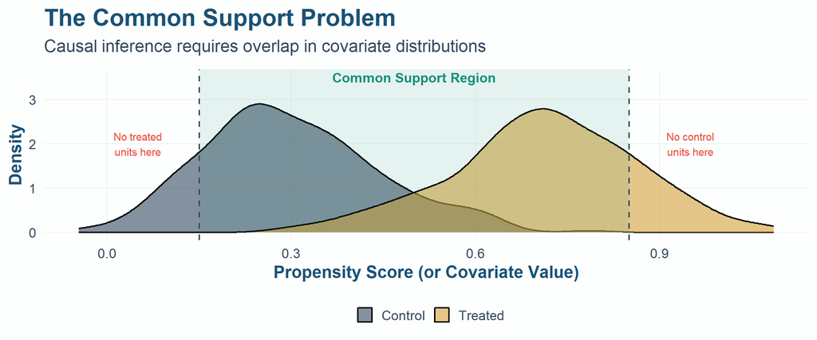

Figure 4: We can only make comparisons where both groups exist

```r
# Generate propensity score-like data
set.seed(123)
n <- 500
ps_data <- tibble(
  x = c(rnorm(n/2, 0.3, 0.15), rnorm(n/2, 0.7, 0.15)),
  treated = rep(c(0, 1), each = n/2)
)

ggplot(ps_data, aes(x = x, fill = factor(treated))) +
  geom_density(alpha = 0.6) +
  geom_vline(xintercept = c(0.15, 0.85), linetype = "dashed", color = slate_gray) +
  annotate("rect", xmin = 0.15, xmax = 0.85, ymin = 0, ymax = Inf,
           fill = secondary_teal, alpha = 0.1) +
  annotate("text", x = 0.5, y = 3.5, label = "Common Support Region",
           color = secondary_teal, fontface = "bold", size = 5) +
  annotate("text", x = 0.05, y = 2, label = "No treated\nunits here",
           color = accent_coral, size = 4) +
  annotate("text", x = 0.95, y = 2, label = "No control\nunits here",
           color = accent_coral, size = 4) +
  scale_fill_manual(values = c(slate_gray, warm_gold),
                    labels = c("Control", "Treated"),
                    name = "") +
  labs(title = "The Common Support Problem",
       subtitle = "Causal inference requires overlap in covariate distributions",
       x = "Propensity Score (or Covariate Value)", y = "Density") +
  theme_health_econ(base_size = 18) +
  theme(legend.position = "bottom")
```

## From Assumptions to Matching

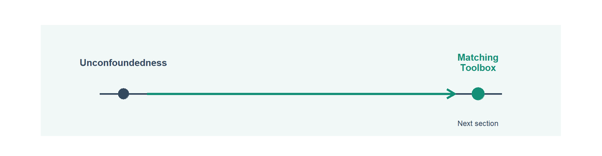

Figure 5

# The Matching Toolbox

Methods for Like-with-Like Comparison

## Strategy 1: Subclassification

**The Idea**

Divide the sample into groups (strata) based on confounders, then compare treated vs. untreated *within* each stratum.

**Steps:**

1. Create strata based on covariate values
2. Calculate treatment effect within each stratum
3. Aggregate using appropriate weights

**Advantage:** Simple, transparent, and forces you to think about comparisons.

**Limitation:** Curse of dimensionality - with many covariates, strata become sparse.

## The Titanic Example: Setup

**Show R Code**

```r
# Load Titanic data
read_data <- function(df) {
  full_path <- paste("https://github.com/scunning1975/mixtape/raw/master/", df, sep = "")
  read_dta(full_path)
}

titanic <- read_data("titanic.dta") %>%
  mutate(
    d = case_when(class == 1 ~ 1, TRUE ~ 0),
    sex_label = ifelse(sex == 0, "Female", "Male"),
    age_label = ifelse(age == 1, "Adult", "Child")
  )

# Simple difference in outcomes
ey1 <- titanic %>% filter(d == 1) %>% pull(survived) %>% mean()
ey0 <- titanic %>% filter(d == 0) %>% pull(survived) %>% mean()
sdo <- ey1 - ey0
```

**Research question:** Did first-class passengers have higher survival rates?

Table 2

| Group | Survival Rate |
| --- | --- |
| First Class | 62.5% |
| Other Classes | 27.1% |
| Simple Difference | 35.4% |

But wait - who was in first class?

## The Titanic Example: Confounders

**Show R Code**

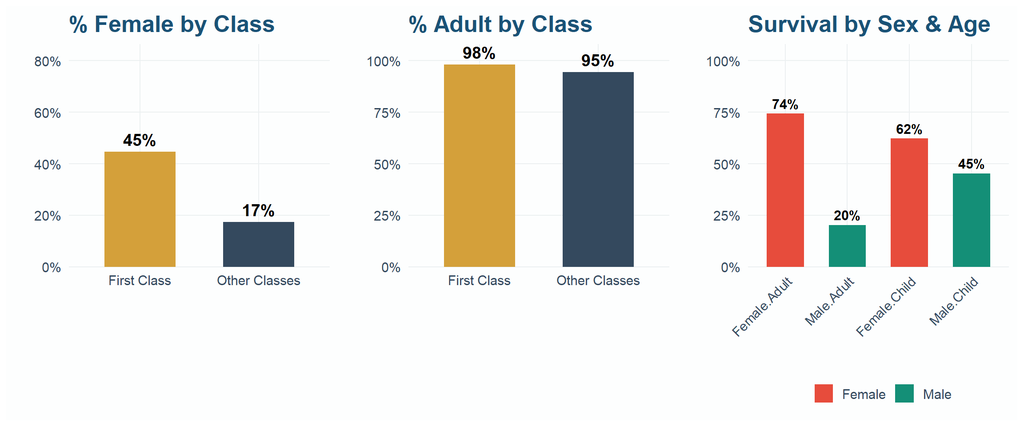

```r
titanic_summary <- titanic %>%
  group_by(d, sex_label, age_label) %>%
  summarize(n = n(), survival = mean(survived), .groups = "drop") %>%
  mutate(class_label = ifelse(d == 1, "First Class", "Other Classes"))

p1 <- titanic %>%
  group_by(d) %>%
  summarize(pct_female = mean(sex_label == "Female"), .groups = "drop") %>%
  mutate(class_label = ifelse(d == 1, "First Class", "Other Classes")) %>%
  ggplot(aes(x = class_label, y = pct_female, fill = class_label)) +
  geom_col(width = 0.6, show.legend = FALSE) +
  geom_text(aes(label = scales::percent(pct_female, accuracy = 1)),
            vjust = -0.5, size = 5, fontface = "bold") +
  scale_fill_manual(values = c(warm_gold, slate_gray)) +
  scale_y_continuous(labels = scales::percent, limits = c(0, 0.8), expand = expansion(mult = c(0, 0.08))) +
  labs(title = "% Female by Class", x = "", y = "") +
  theme_health_econ(base_size = 14)

p2 <- titanic %>%
  group_by(d) %>%
  summarize(pct_adult = mean(age_label == "Adult"), .groups = "drop") %>%
  mutate(class_label = ifelse(d == 1, "First Class", "Other Classes")) %>%
  ggplot(aes(x = class_label, y = pct_adult, fill = class_label)) +
  geom_col(width = 0.6, show.legend = FALSE) +
  geom_text(aes(label = scales::percent(pct_adult, accuracy = 1)),
            vjust = -0.5, size = 5, fontface = "bold") +
  scale_fill_manual(values = c(warm_gold, slate_gray)) +
  scale_y_continuous(labels = scales::percent, limits = c(0, 1), expand = expansion(mult = c(0, 0.08))) +
  labs(title = "% Adult by Class", x = "", y = "") +
  theme_health_econ(base_size = 14)

p3 <- titanic %>%
  group_by(sex_label, age_label) %>%
  summarize(survival = mean(survived), .groups = "drop") %>%
  ggplot(aes(x = interaction(sex_label, age_label), y = survival,
             fill = sex_label)) +
  geom_col(width = 0.6) +
  geom_text(aes(label = scales::percent(survival, accuracy = 1)),
            vjust = -0.5, size = 4, fontface = "bold") +
  scale_fill_manual(values = c(accent_coral, secondary_teal), name = "") +
  scale_y_continuous(labels = scales::percent, limits = c(0, 1), expand = expansion(mult = c(0, 0.08))) +
  labs(title = "Survival by Sex & Age", x = "", y = "") +
  theme_health_econ(base_size = 14) +
  theme(axis.text.x = element_text(angle = 45, hjust = 1))

p1 + p2 + p3
```

## Subclassification in Action

**Show R Code**

```r
# Create strata
titanic <- titanic %>%
  mutate(stratum = case_when(
    sex == 0 & age == 1 ~ "Male Adult",
    sex == 0 & age == 0 ~ "Male Child",
    sex == 1 & age == 1 ~ "Female Adult",
    sex == 1 & age == 0 ~ "Female Child"
  ))

# Calculate within-stratum effects
stratum_effects <- titanic %>%
  group_by(stratum, d) %>%
  summarize(survival = mean(survived), n = n(), .groups = "drop") %>%
  pivot_wider(names_from = d, values_from = c(survival, n), names_prefix = "d") %>%
  mutate(
    effect = survival_d1 - survival_d0,
    weight = (n_d0 + n_d1) / sum(n_d0 + n_d1)
  )

# Weighted average treatment effect
wate <- sum(stratum_effects$effect * stratum_effects$weight)
```

Table 3

[output not shown]

First class still helped survival, but **less than the naive comparison suggested**.

## Strategy 2: Exact Matching

**The Idea**

For each treated unit, find a control unit with *identical* covariate values.

**Identical to subclassification** when feasible, but:

- Fails with continuous covariates
- Fails when strata are sparse (curse of dimensionality)
- Many treated units may go unmatched

**When it works:** Binary/categorical confounders with sufficient sample size in each cell.

## Strategy 3: Nearest Neighbor Matching

When exact matching fails, find the *closest* match instead.

**Distance Metrics:**

Table 4

| Metric | Formula | When to Use |
| --- | --- | --- |
| Euclidean | $\sqrt{\sum_k (X_{ik} - X_{jk})^2}$ | Similar scales |
| Normalized Euclidean | $\sqrt{\sum_k \left(\frac{X_{ik} - X_{jk}}{\sigma_k}\right)^2}$ | Different scales |
| Mahalanobis | $\sqrt{(X_i - X_j)' S^{-1} (X_i - X_j)}$ | Correlated covariates |

## Strategy 4: Coarsened Exact Matching (CEM)

**The Clever Compromise**

Bin continuous variables into categories, then do exact matching on the bins.

**Steps:**

1. **Coarsen:** Convert continuous variables to bins (e.g., age -> age groups)
2. **Match:** Exact match on coarsened values
3. **Prune:** Drop strata without both treated and control units
4. **Weight:** Compute stratum weights for remaining observations

**Key insight:** You control the bias-variance tradeoff by choosing bin widths.

## Visualizing CEM

**Show R Code**

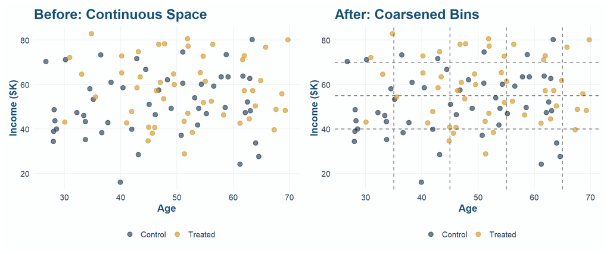

Figure 7: CEM bins continuous variables then matches exactly within bins

```r
set.seed(456)
n <- 100
cem_data <- tibble(
  age = c(runif(n/2, 25, 65), runif(n/2, 30, 70)),
  income = c(rnorm(n/2, 50, 15), rnorm(n/2, 60, 15)),
  treated = rep(c(0, 1), each = n/2)
) %>%
  mutate(
    age_bin = cut(age, breaks = c(25, 35, 45, 55, 65, 75), include.lowest = TRUE),
    income_bin = cut(income, breaks = c(0, 40, 55, 70, 100, 140), include.lowest = TRUE)
  )

p1 <- ggplot(cem_data, aes(x = age, y = income, color = factor(treated))) +
  geom_point(size = 3, alpha = 0.7) +
  scale_color_manual(values = c(slate_gray, warm_gold),
                     labels = c("Control", "Treated"), name = "") +
  labs(title = "Before: Continuous Space", x = "Age", y = "Income ($K)") +
  theme_health_econ(base_size = 14) +
  theme(legend.position = "bottom")

p2 <- ggplot(cem_data, aes(x = age, y = income, color = factor(treated))) +
  geom_point(size = 3, alpha = 0.7) +
  geom_vline(xintercept = c(35, 45, 55, 65), linetype = "dashed", alpha = 0.5) +
  geom_hline(yintercept = c(40, 55, 70), linetype = "dashed", alpha = 0.5) +
  scale_color_manual(values = c(slate_gray, warm_gold),
                     labels = c("Control", "Treated"), name = "") +
  labs(title = "After: Coarsened Bins", x = "Age", y = "Income ($K)") +
  theme_health_econ(base_size = 14) +
  theme(legend.position = "bottom")

p1 + p2
```

## From Matching to Propensity Scores

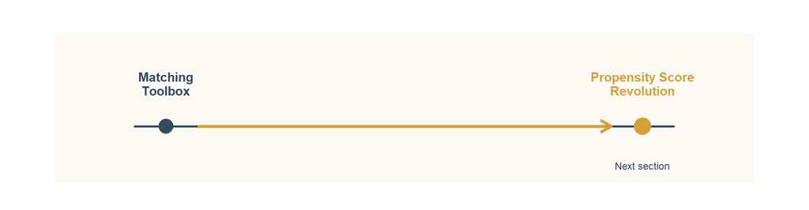

Figure 8

# The Propensity Score Revolution

Balancing Many Covariates with One Score

## The Dimensionality Problem

With $K$ covariates, matching becomes exponentially harder:

- 2 binary covariates -> 4 strata
- 5 binary covariates -> 32 strata
- 10 binary covariates -> 1,024 strata

**Rosenbaum & Rubin’s insight (1983):** We don’t need to match on all covariates separately. We can collapse them into a single number.

## The Propensity Score

**Definition**

The propensity score is the probability of receiving treatment given observed covariates:

$$e(X) = Pr(D = 1 \\mid X)$$

**Key theorem:** If unconfoundedness holds given $X$, it also holds given $e(X)$.

$$(Y^1, Y^0) \perp\!\!\!\perp D \\mid X \implies (Y^1, Y^0) \perp\!\!\!\perp D \\mid e(X)$$

**Implication:** Instead of matching on many variables, we can match on this single scalar!

## Estimating Propensity Scores

**Show R Code**

```r
# Generate example data with multiple confounders
set.seed(789)
n <- 1000
ps_example <- tibble(
  age = rnorm(n, 45, 12),
  income = rnorm(n, 55, 20),
  education = rbinom(n, 1, 0.4),
  chronic = rbinom(n, 1, 0.3)
) %>%
  mutate(
    # True propensity score model
    ps_true = plogis(-2 + 0.03 * age + 0.02 * income + 0.5 * education + 0.8 * chronic),
    treated = rbinom(n, 1, ps_true)
  )

# Estimate propensity score
ps_model <- glm(treated ~ age + income + education + chronic,
                data = ps_example, family = binomial)
ps_example$ps_hat <- predict(ps_model, type = "response")
```

**Show R Code**

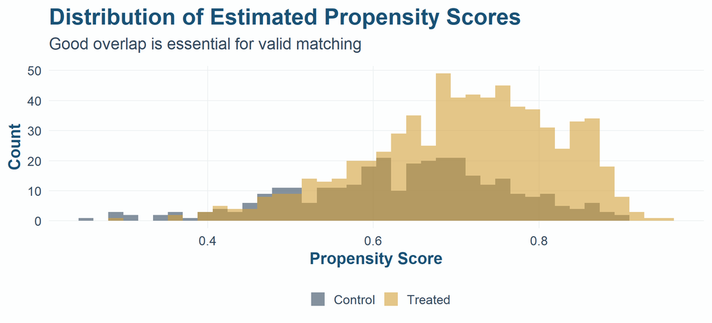

Figure 9: Propensity scores should overlap between groups

```r
ggplot(ps_example, aes(x = ps_hat, fill = factor(treated))) +
  geom_histogram(alpha = 0.6, position = "identity", bins = 40) +
  scale_fill_manual(values = c(slate_gray, warm_gold),
                    labels = c("Control", "Treated"), name = "") +
  labs(
    title = "Distribution of Estimated Propensity Scores",
    subtitle = "Good overlap is essential for valid matching",
    x = "Propensity Score", y = "Count"
  ) +
  theme_health_econ(base_size = 18) +
  theme(legend.position = "bottom")
```

## Using Propensity Scores

Two main approaches:

### Matching

- Match treated to control with similar $\hat{e}(X)$
- Can use nearest neighbor, caliper, etc.
- Discards unmatched units

```r
# With MatchIt
m <- matchit(treat ~ x1 + x2,
             data = df,
             method = "nearest",
             distance = "glm")
```

### Weighting (IPW)

- Upweight “surprising” observations
- Treated: $w = 1/\hat{e}(X)$ (low-propensity treated are informative)
- Control: $w = 1/(1-\hat{e}(X))$
- Keeps all observations

```r
# Create IPW weights
df$ipw <- ifelse(df$treat == 1,
                 1/df$ps,
                 1/(1-df$ps))
```

**Graduate Students: ATT vs. ATE Weights**

For ATT: Weight controls by $\hat{e}(X)/(1-\hat{e}(X))$, treated units get weight 1. For ATE: Weight treated by $1/\hat{e}(X)$, controls by $1/(1-\hat{e}(X))$. Normalized versions divide by sum of weights to improve stability.

## Checking Balance

After matching/weighting, check that covariates are balanced:

**Show R Code**

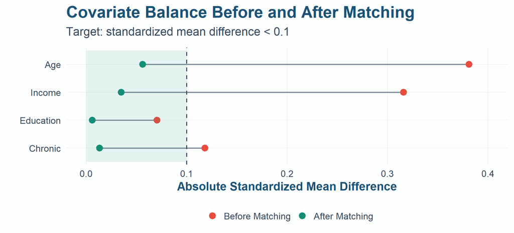

Figure 10: Standardized mean differences should be small (< 0.1) after matching

```r
# Perform matching
m_out <- matchit(
  treated ~ age + income + education + chronic,
  data = ps_example,
  method = "nearest",
  distance = "glm",
  caliper = 0.2,
  replace = TRUE,
  estimand = "ATT"
)

# Extract balance statistics (pre and post)
bal_tab <- bal.tab(m_out, un = TRUE)
bal_stats <- bal_tab$Balance
vars <- c("age", "income", "education", "chronic")

balance_wide <- tibble(
  variable = c("Age", "Income", "Education", "Chronic"),
  before = abs(bal_stats[vars, "Diff.Un"]),
  after = abs(bal_stats[vars, "Diff.Adj"])
)

balance_long <- balance_wide %>%
  pivot_longer(cols = c(before, after), names_to = "timing", values_to = "smd") %>%
  mutate(
    timing = factor(timing, levels = c("before", "after"),
                    labels = c("Before Matching", "After Matching")),
    variable = factor(variable, levels = rev(c("Age", "Income", "Education", "Chronic")))
  )

ggplot(balance_long, aes(y = variable)) +
  geom_segment(
    data = balance_wide,
    aes(x = before, xend = after, yend = factor(variable, levels = rev(c("Age", "Income", "Education", "Chronic")))),
    color = slate_gray, linewidth = 1, alpha = 0.6
  ) +
  geom_point(aes(x = smd, color = timing), size = 4) +
  geom_vline(xintercept = 0.1, linetype = "dashed", color = slate_gray) +
  annotate("rect", xmin = 0, xmax = 0.1, ymin = 0.5, ymax = 4.5,
           fill = secondary_teal, alpha = 0.1) +
  scale_color_manual(values = c(accent_coral, secondary_teal), name = "") +
  labs(
    title = "Covariate Balance Before and After Matching",
    subtitle = "Target: standardized mean difference < 0.1",
    x = "Absolute Standardized Mean Difference", y = ""
  ) +
  theme_health_econ(base_size = 18) +
  theme(legend.position = "bottom") +
  xlim(0, 0.4)
```

## From Scores to Regression

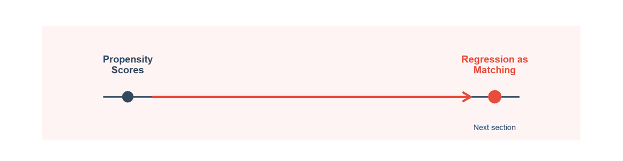

Figure 11

# Regression as Matching

What OLS Is Doing Under the Hood

## OLS: The Implicit Matching Estimator

The familiar regression:

$$Y_i = \alpha + \delta D_i + \beta X_i + \varepsilon_i$$

Under the hood, OLS is doing a form of covariate adjustment - but with strong assumptions:

1. **Linearity:** Treatment effect is constant across $X$
2. **Constant effects:** No treatment effect heterogeneity
3. **Correct specification:** Functional form is right

## When OLS Works (and When It Doesn’t)

**Show R Code**

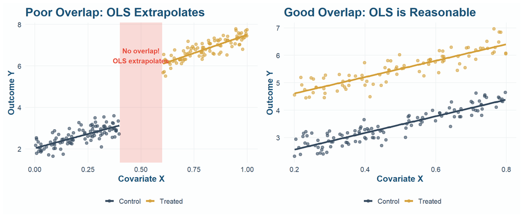

Figure 12: OLS extrapolates; matching interpolates

```r
set.seed(101)
n <- 200
ols_data <- tibble(
  x = c(runif(n/2, 0, 0.4), runif(n/2, 0.6, 1)),
  treated = rep(c(0, 1), each = n/2),
  y = 2 + 3 * x + 2 * treated + 0.5 * x * treated + rnorm(n, 0, 0.3)
)

p1 <- ggplot(ols_data, aes(x = x, y = y, color = factor(treated))) +
  geom_point(alpha = 0.6, size = 2) +
  geom_smooth(method = "lm", se = FALSE, linewidth = 1.5) +
  annotate("rect", xmin = 0.4, xmax = 0.6, ymin = -Inf, ymax = Inf,
           fill = accent_coral, alpha = 0.2) +
  annotate("text", x = 0.5, y = 6.5, label = "No overlap!\nOLS extrapolates",
           color = accent_coral, fontface = "bold", size = 4) +
  scale_color_manual(values = c(slate_gray, warm_gold),
                     labels = c("Control", "Treated"), name = "") +
  labs(title = "Poor Overlap: OLS Extrapolates",
       x = "Covariate X", y = "Outcome Y") +
  theme_health_econ(base_size = 14) +
  theme(legend.position = "bottom")

# Good overlap data
ols_data2 <- tibble(
  x = runif(n, 0.2, 0.8),
  treated = rbinom(n, 1, 0.5),
  y = 2 + 3 * x + 2 * treated + rnorm(n, 0, 0.3)
)

p2 <- ggplot(ols_data2, aes(x = x, y = y, color = factor(treated))) +
  geom_point(alpha = 0.6, size = 2) +
  geom_smooth(method = "lm", se = FALSE, linewidth = 1.5) +
  scale_color_manual(values = c(slate_gray, warm_gold),
                     labels = c("Control", "Treated"), name = "") +
  labs(title = "Good Overlap: OLS is Reasonable",
       x = "Covariate X", y = "Outcome Y") +
  theme_health_econ(base_size = 14) +
  theme(legend.position = "bottom")

p1 + p2
```

## Summary: Choosing Your Method

Table 5

| Method | Best For | Key Limitation |
| --- | --- | --- |
| Subclassification | Few discrete covariates | Curse of dimensionality |
| Exact Matching | Categorical variables, large N | Sparse cells |
| Nearest Neighbor | Continuous covariates | Matching bias |
| CEM | Mix of variable types | Changes estimand |
| Propensity Score | Many covariates | Model dependence |
| OLS | Good overlap, linear effects | Extrapolation risk |

**Best practice:** Use multiple methods as sensitivity checks. If results are robust across approaches, you can be more confident.

## From Method to Application

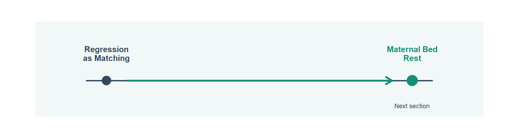

Figure 13

# Application: Maternal Bed Rest

Putting the Design into Practice Durrance and Guldi (2015)

## Maternal Bed Rest and Infant Health Outcomes

### Skim the paper and think about the following:

1. What is the main objective or research question?
2. What methods are they using?
3. What are the primary issues with the method(s) and how do they solve it? Think CIA.
4. What are the main results?
5. What are the policy implications?

## The Research Question

**Durrance & Guldi (2015):** Does prescribed bed rest during pregnancy improve infant health?

**The Challenge:**

- Women prescribed bed rest have pregnancy complications
- Complications also cause poor infant outcomes
- Naive comparison is confounded!

**Data:** Pregnancy Risk Assessment Monitoring System (PRAMS)

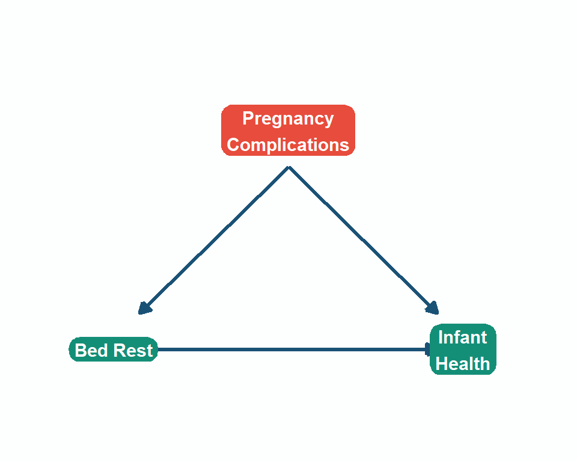

Figure 14

## The Naive Result

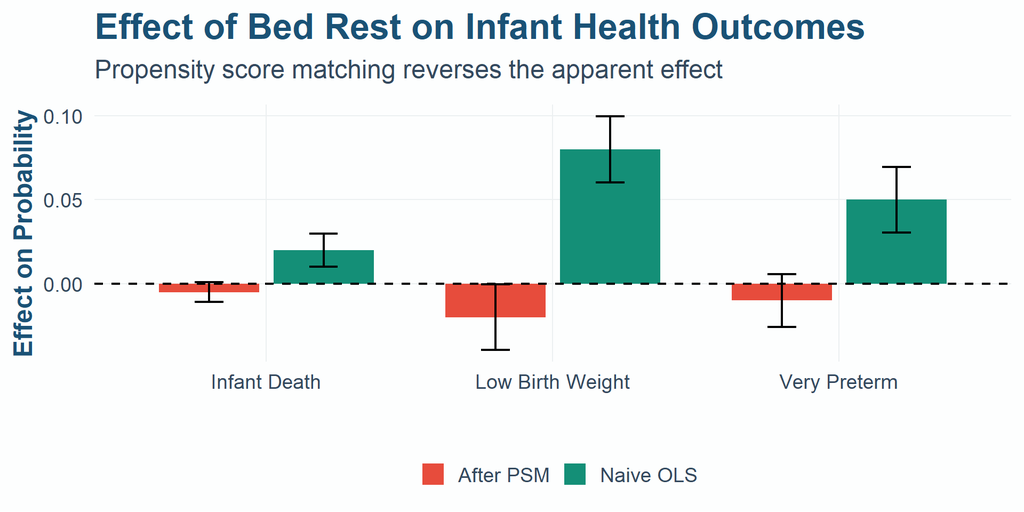

Figure 15: Naive comparison suggests bed rest is harmful!

## Key Findings

After propensity score matching on pregnancy complications and demographics:

Without proper comparison groups, we would have concluded the opposite of the truth.

## Key Takeaways

### What We Learned

1. Selection bias distorts naive comparisons
2. Unconfoundedness requires observing *all* confounders
3. Common support limits where we can make inferences
4. Multiple methods exist - each with tradeoffs
5. Balance checking is essential

### The Big Picture

Matching and weighting are tools for **constructing counterfactuals**.

They work when:

- We observe the right variables
- Groups have overlap
- We check our assumptions

> “All models are wrong, but some are useful.”

## Looking Ahead

**Coming Up**

- **Instrumental Variables:** When unconfoundedness fails
- **Regression Discontinuity:** Exploiting sharp thresholds
- **Difference-in-Differences:** Before-after with comparison groups

## Discussion Questions

1. **Hospital quality study:** What confounders would you want to control for when comparing outcomes across hospitals?
2. **Propensity score paradox:** Why might controlling for *too many* variables actually hurt your analysis?
3. **Bed rest study:** What unmeasured confounders might still bias the propensity score results?

## References & Resources

**Key Papers:** Rosenbaum & Rubin (1983) “The Central Role of the Propensity Score”; Abadie & Imbens (2011) “Bias-Corrected Matching Estimators”

**Textbooks:** Angrist & Pischke (2009) *Mostly Harmless Econometrics*; Cunningham (2021) [*Causal Inference: The Mixtape*](https://mixtape.scunning.com/)

**This Deck:** Companion R script (`unconfoundedness_walkthrough.R`) available for hands-on practice

## From Application to Appendix

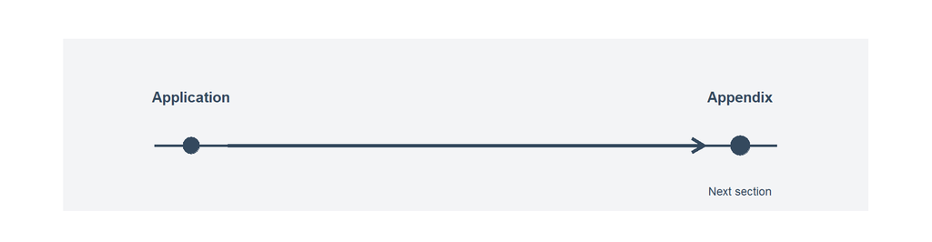

Figure 16

# Appendix: Advanced Topics

## Doubly Robust Estimation

Combines propensity score weighting with outcome regression:

$$\hat{\tau}_{DR} = \frac{1}{n}\sum_{i=1}^{n}\left[\frac{D_i Y_i}{\hat{e}(X_i)} - \frac{(D_i - \hat{e}(X_i))\hat{\mu}_1(X_i)}{\hat{e}(X_i)}\right] - \frac{1}{n}\sum_{i=1}^{n}\left[\frac{(1-D_i) Y_i}{1-\hat{e}(X_i)} + \frac{(D_i - \hat{e}(X_i))\hat{\mu}_0(X_i)}{1-\hat{e}(X_i)}\right]$$

**Why “doubly robust”?** Consistent if *either* the propensity score model *or* the outcome model is correctly specified.

**Practical Advantage**

You get two chances to get the model right. Even if one model is misspecified, you may still get consistent estimates.

## Sensitivity Analysis

Since unconfoundedness is untestable, we can ask: **How much unmeasured confounding would be needed to overturn our results?**

**Rosenbaum bounds:** For matched pairs, test how sensitive results are to a hypothetical unmeasured confounder.

- $\Gamma = 1$: No unmeasured confounding
- $\Gamma = 2$: Unmeasured confounder doubles odds of treatment
- If results hold at $\Gamma = 2$, fairly robust

**Interpretation**

“Results would be overturned if an unmeasured confounder increased treatment odds by 50% and also affected outcomes.” - This gives readers a sense of how worried to be.

## Machine Learning for Propensity Scores

Modern approaches use flexible ML methods:

**Advantages:**

- Capture nonlinear relationships automatically
- Less model dependence than logistic regression
- Can handle many covariates

**Common methods:**

- Random forests / Gradient boosting
- LASSO / Elastic net
- Ensemble methods (SuperLearner)

**Caution**

ML optimizes *prediction*, not *balance*. Always check covariate balance after matching, regardless of how propensity scores were estimated.

## Variance Estimation

Standard errors for matching estimators are tricky:

**Issues:**

- Matching creates dependence between observations
- Propensity scores are estimated, not known
- Weights may be extreme

**Solutions:**

1. **Abadie-Imbens variance estimator:** Accounts for matching
2. **Bootstrap:** Resample and re-match each iteration
3. **Linearization:** Approximate variance analytically

**Practical Advice**

Use package defaults (e.g., `MatchIt` + `marginaleffects`) which implement appropriate variance estimators. For IPW, use robust standard errors.